# Curricular Analytics Modeling

Requisite libraries

```r
library(readxl)
library(themis)
library(ggplot2)
library(dplyr)
library(stringr)
library(tidyr)
library(pROC)
library(randomForest)
library(caret)
library(CurricularAnalytics)
```

This section is responsible for performing initial preprocessing on cohort course level data by creating variables for cohort, removing columns, creating variable for 1st year retention, denoting core classes as apart of curricula, and calculating preliminary student statistics from the cohort level data.

```r
prev_cohorts <- read_xlsx("C:/Users/cpanc/OneDrive/Documents/IDC6940/FIU/HISTORICAL DATA/Course Takers COMPSCBS.xlsx")

prev_cohorts <- prev_cohorts %>%  distinct(.keep_all = TRUE)

# names(prev_cohorts)

###############################################
### convert all dates to homogeneous format ###
###############################################

# a - convert TERM_DESC to 1241 format
TermKey <- prev_cohorts[,c("TERM_DESC"), drop=F]
TermKey <- unique(TermKey) #remove duplicate rows

# ie: Fall 2023 -> A: Fall, B: 2023
TermKey <- separate(TermKey, `TERM_DESC`, c("A", "B"))
TermKey$first <- 1
TermKey$second <- substr(TermKey$B, start=3, stop=4)
TermKey$third <- ifelse(TermKey$A == "Fall", 8,
  ifelse(TermKey$A =="Spring", 1,                               ifelse(TermKey$A == "Summer", 5, "")))
TermKey$TERM_NUM <- paste(TermKey$first, TermKey$second, TermKey$third,sep="")
TermKey$TERM_DESC <- paste(TermKey$A, TermKey$B)
TermKey <- TermKey %>% select(TERM_DESC, TERM_NUM)
prev_cohorts <- merge(prev_cohorts, TermKey, by=c("TERM_DESC"), all.x=TRUE ) %>% relocate(TERM_NUM, .after = TERM_DESC)

# b - convert COH_FIRST_TERM_ATTND, COH_LAST_TERM_ATTND, MAJOR_CHANGE_TERM_ID to other date format
TermKey <- prev_cohorts[,c("COH_FIRST_TERM_ATTND", "COH_LAST_TERM_ATTND",  "MAJOR_CHANGE_TERM_ID"), drop=F]
TermKey <- unique(TermKey)
TermKey$first <- 1
TermKey$cohsecond <- substr(TermKey$COH_LAST_TERM_ATTND, start=3, stop=4)
TermKey$firsecond <- substr(TermKey$COH_FIRST_TERM_ATTND, start=3, stop=4)
TermKey$majsecond <- substr(TermKey$MAJOR_CHANGE_TERM_ID, start=3, stop=4)
TermKey$firthird <- substr(TermKey$COH_FIRST_TERM_ATTND, start=6, stop=6)
TermKey$cohthird <- substr(TermKey$COH_LAST_TERM_ATTND, start=6, stop=6)
TermKey$majthird <- substr(TermKey$MAJOR_CHANGE_TERM_ID, start=6, stop=6)

TermKey$COH_FIRST_TERM_ATTND_NUM <- paste(TermKey$first, TermKey$firsecond, TermKey$firthird,sep="")
TermKey$COH_LAST_TERM_ATTND_NUM <- paste(TermKey$first, TermKey$cohsecond, TermKey$cohthird,sep="")
TermKey$MAJOR_CHANGE_TERM_ID_NUM <- paste(TermKey$first, TermKey$majsecond, TermKey$majthird,sep="") %>% na_if('1NANA')

TermKey <- TermKey %>% select(COH_FIRST_TERM_ATTND, COH_FIRST_TERM_ATTND_NUM, COH_LAST_TERM_ATTND, COH_LAST_TERM_ATTND_NUM, MAJOR_CHANGE_TERM_ID,MAJOR_CHANGE_TERM_ID_NUM )

prev_cohorts <- merge(prev_cohorts, TermKey, by=c("COH_LAST_TERM_ATTND", "MAJOR_CHANGE_TERM_ID", "COH_FIRST_TERM_ATTND"), all.x=TRUE )

#unique(prev_cohorts$COH_FIRST_TERM_ATTND)

##########################################################
######### dropping redundant columns, remove NA ##########
##########################################################

# COH_FIRST_TERM redundant, TERM_ID replaced with TERM_NUM, and I dont see how instructor adjunct status relevant
prev_cohorts <- prev_cohorts %>%
  select( -ftpt_stat_instructor, -eab_payplan_grp, -TERM_ID, -COH_LAST_TERM_ATTND, -MAJOR_CHANGE_TERM_ID, -COH_FIRST_TERM_ATTND) %>%
  relocate(id_code_taker, .before = TERM_DESC) %>%
  relocate(c(COHORT, COH_FIRST_TERM_ATTND_NUM, COH_LAST_TERM_ATTND_NUM, MAJOR_CHANGE_TERM_ID_NUM), .before = COURSE)

prev_cohorts <- prev_cohorts %>% group_by(id_code_taker) %>%
  fill(REQ_TERM, .direction = "downup") %>% ungroup()

# which(is.na(prev_cohorts$REQ_TERM))

###############################################
###### to predict 1st/2nd year retention ######
###############################################

FIRST_YR_RETENTION <- prev_cohorts %>%
  group_by(id_code_taker) %>% mutate(
    year2 = as.double(COH_FIRST_TERM_ATTND_NUM) + 10,
    firstYR_RETENTION = any(as.double(TERM_NUM) >= year2)
    ) %>%
  distinct(id_code_taker, firstYR_RETENTION)

prev_cohorts <- merge(prev_cohorts,FIRST_YR_RETENTION, by=c("id_code_taker"), all.x = T)

prev_cohorts$firstYR_RETENTION <- as.integer(as.logical(prev_cohorts$firstYR_RETENTION))

###############################################
###### switch or stay in major ################
###############################################

prev_cohorts$switchmajor <- ifelse(prev_cohorts$outcome == 'Switch and not graduate' | prev_cohorts$outcome == 'Switch and Graduate', 1, 0)

###############################################
###### denoting which courses are 'core' ######
###############################################

# the old course maps for FIU don't work because the UCC requirements are different
req_map <- read.csv("C:/Users/cpanc/OneDrive/Documents/IDC6940/FIU/HISTORICAL DATA/UCC_and_courses_mapping.csv")

prev_cohorts <- full_join(req_map, prev_cohorts, by = "COURSE_ID")

prev_cohorts$INCURRICULA <- ifelse(is.na(prev_cohorts$map),0,1)

prev_cohorts <- prev_cohorts %>%
  mutate(map = ifelse(is.na(map), COURSE_ID, map)) %>%
  select(-COURSE_ID) %>% rename("COURSE_ID"=map)

prev_cohorts <- prev_cohorts %>%  distinct(.keep_all = TRUE) %>% drop_na(id_code_taker)

###############################################
#### calculating stats for 1 yrs in cohort ####
###############################################

cohort_1_yr_stat <- prev_cohorts %>% group_by(id_code_taker) %>% mutate(twoyr = as.double(COH_FIRST_TERM_ATTND_NUM) + 10) %>% filter(as.double(TERM_NUM) < twoyr) %>% select(-twoyr) %>% ungroup()

grad_1yr_pred <- cohort_1_yr_stat %>% group_by(id_code_taker) %>% summarize(
  COHORT = first(COH_FIRST_TERM_ATTND_NUM),
  TOTAL_ATTEMPTED_COURSES = n(),
  CORE_CLASSES_SUCCESS = sum(INCURRICULA==1 & pass==1) / sum(INCURRICULA==1),
  TOTAL_FAILED = sum(pass==0),
  PASS_RATE = sum(pass==1) / TOTAL_ATTEMPTED_COURSES,
  GRAD = first(graduated),
  SWITCH = first(switchmajor),
  OUTCOME = first(outcome)
)  %>%  mutate(
    GRAD = factor(GRAD, levels = c(0,1)),
    SWITCH = factor(SWITCH, levels = c(0,1)),
    OUTCOME_LABEL = factor(OUTCOME)
)

###############################################
#### calculating stats for 2 yrs in cohort ####
###############################################

cohort_2_yr_stat <- prev_cohorts %>% group_by(id_code_taker) %>% mutate(twoyr = as.double(COH_FIRST_TERM_ATTND_NUM) + 20) %>% filter(as.double(TERM_NUM) < twoyr) %>% select(-twoyr) %>% ungroup()

grad_preds <- cohort_2_yr_stat %>% group_by(id_code_taker) %>% summarize(
  COHORT = first(COH_FIRST_TERM_ATTND_NUM),
  TOTAL_ATTEMPTED_COURSES = n(),
  CORE_CLASSES_SUCCESS = sum(INCURRICULA==1 & pass==1) / sum(INCURRICULA==1),
  TOTAL_FAILED = sum(pass==0),
  PASS_RATE = sum(pass==1) / TOTAL_ATTEMPTED_COURSES,
  GRAD = first(graduated),
  SWITCH = first(switchmajor),
  OUTCOME = first(outcome)
)  %>%  mutate(
    GRAD = factor(GRAD, levels = c(0,1)),
    SWITCH = factor(SWITCH, levels = c(0,1)),
    OUTCOME_LABEL = factor(OUTCOME)
)
```

We create base models without curricular analytics to set a performance benchmark. The models created use subset of cohort data from 1 year to 2 years of cohort data. There are two models: a binary classifier predicting student graduation outcomes and a second binary classification model predicting student persistence in the computer science major. We use 5 fold cross validation with undersampling the majority class.

```r
set.seed(227)

train_index  <- createDataPartition(y=grad_preds$GRAD, p=0.7, list=FALSE)

repeat_cv <- trainControl(method='repeatedcv', number=5, repeats=3, sampling='down')

train_dfB <- grad_preds[train_index, ] # index in
test_dfB  <- grad_preds[-train_index, ] # index out

train_dfYEAR <- grad_1yr_pred[train_index,]
test_dfYEAR <- grad_1yr_pred[-train_index,]
```

Binary classifiers for predicting student graduation and evaluating said models with confusion matrix, ROC-AUC, and highlighting which variables contributed most or least to predicting a class using random forest built in importance features.

```r
set.seed(227)
rf_model1 <- train(
  GRAD ~ COHORT + TOTAL_ATTEMPTED_COURSES + CORE_CLASSES_SUCCESS +
    TOTAL_FAILED + PASS_RATE,
  data = train_dfB,
  method='rf',
  trControl=repeat_cv,
  metric='Accuracy'
)

#rf_model1

# using 1yr of cohort data
rf_model_1yr <- train(
  GRAD ~ COHORT + TOTAL_ATTEMPTED_COURSES + CORE_CLASSES_SUCCESS +
    TOTAL_FAILED + PASS_RATE,
  data = train_dfYEAR,
  method='rf',
  trControl=repeat_cv,
  metric='Accuracy'
)
rf_model_1yr
```

```
Random Forest

280 samples
  5 predictor
  2 classes: '0', '1'

No pre-processing
Resampling: Cross-Validated (5 fold, repeated 3 times)
Summary of sample sizes: 225, 224, 223, 223, 225, 224, ...
Addtional sampling using down-sampling

Resampling results across tuning parameters:

  mtry  Accuracy   Kappa
  2     0.6961916  0.2944687
  5     0.6358309  0.1995810
  8     0.5896461  0.1391391

Accuracy was used to select the optimal model using the largest value.
The final value used for the model was mtry = 2.
```

```r
################ 2yrs model###############################
pred <- predict(rf_model1, newdata = test_dfB)
xtab <- table(pred, test_dfB$GRAD)
caret::confusionMatrix(data = xtab, positive = '1',  mode = "everything")
```

```
Confusion Matrix and Statistics


pred  0  1
   0 17 23
   1 11 67

               Accuracy : 0.7119
                 95% CI : (0.6213, 0.7915)
    No Information Rate : 0.7627
    P-Value [Acc > NIR] : 0.91784

                  Kappa : 0.3064

 Mcnemar's Test P-Value : 0.05923

            Sensitivity : 0.7444
            Specificity : 0.6071
         Pos Pred Value : 0.8590
         Neg Pred Value : 0.4250
              Precision : 0.8590
                 Recall : 0.7444
                     F1 : 0.7976
             Prevalence : 0.7627
         Detection Rate : 0.5678
   Detection Prevalence : 0.6610
      Balanced Accuracy : 0.6758

       'Positive' Class : 1
```

```r
prob <- predict(rf_model1, newdata = test_dfB, type = "prob")[,2]
roc_obj <- roc(test_dfB$GRAD, prob)
auc(roc_obj)
```

```
Area under the curve: 0.756
```

```r
importance(rf_model1$finalModel)
```

```
                        MeanDecreaseGini
COHORT1198                      1.651878
COHORT1208                      1.672222
COHORT1218                      2.225800
COHORT1228                      1.339702
TOTAL_ATTEMPTED_COURSES         9.525469
CORE_CLASSES_SUCCESS           13.012983
TOTAL_FAILED                   10.318790
PASS_RATE                      13.081425
```

```r
var_imp <- varImp(rf_model1, scale=FALSE)$importance

################ 1 yr model ##################################
print("BASE BINARY MODEL - 1yrs COHORT data")
```

```
[1] "BASE BINARY MODEL - 1yrs COHORT data"
```

```r
pred <- predict(rf_model_1yr, newdata = test_dfYEAR)
xtab <- table(pred, test_dfYEAR$GRAD)
caret::confusionMatrix(data = xtab, positive = '1',  mode = "everything")
```

```
Confusion Matrix and Statistics


pred  0  1
   0 20 23
   1  8 67

               Accuracy : 0.7373
                 95% CI : (0.6483, 0.814)
    No Information Rate : 0.7627
    P-Value [Acc > NIR] : 0.77799

                  Kappa : 0.3873

 Mcnemar's Test P-Value : 0.01192

            Sensitivity : 0.7444
            Specificity : 0.7143
         Pos Pred Value : 0.8933
         Neg Pred Value : 0.4651
              Precision : 0.8933
                 Recall : 0.7444
                     F1 : 0.8121
             Prevalence : 0.7627
         Detection Rate : 0.5678
   Detection Prevalence : 0.6356
      Balanced Accuracy : 0.7294

       'Positive' Class : 1
```

```r
prob <- predict(rf_model_1yr, newdata = test_dfB, type = "prob")[,2]
roc_obj <- roc(test_dfYEAR$GRAD, prob)
auc(roc_obj)
```

```
Area under the curve: 0.8073
```

```r
importance(rf_model_1yr$finalModel)
```

```
                        MeanDecreaseGini
COHORT1198                      1.695769
COHORT1208                      1.852261
COHORT1218                      1.541655
COHORT1228                      2.400702
TOTAL_ATTEMPTED_COURSES         8.702625
CORE_CLASSES_SUCCESS           10.077875
TOTAL_FAILED                    7.405368
PASS_RATE                      10.566658
```

```r
var_imp <- varImp(rf_model_1yr, scale=FALSE)$importance
```

Binary classifiers for switching majors.

```r
rf_model2 <- train(
  SWITCH ~ COHORT + TOTAL_ATTEMPTED_COURSES + CORE_CLASSES_SUCCESS +
    TOTAL_FAILED + PASS_RATE,
  data = train_dfB,
  method='rf',
  trControl=repeat_cv,
  metric='Accuracy'
)
rf_model2
```

```
Random Forest

280 samples
  5 predictor
  2 classes: '0', '1'

No pre-processing
Resampling: Cross-Validated (5 fold, repeated 3 times)
Summary of sample sizes: 225, 224, 223, 224, 224, 224, ...
Addtional sampling using down-sampling

Resampling results across tuning parameters:

  mtry  Accuracy   Kappa
  2     0.7738331  0.4765554
  5     0.7607781  0.4334129
  8     0.7546370  0.4370035

Accuracy was used to select the optimal model using the largest value.
The final value used for the model was mtry = 2.
```

```r
rf_model2_1yr <- train(
  SWITCH ~ COHORT + TOTAL_ATTEMPTED_COURSES + CORE_CLASSES_SUCCESS +
    TOTAL_FAILED + PASS_RATE,
  data = train_dfYEAR,
  method='rf',
  trControl=repeat_cv,
  metric='Accuracy'
)
rf_model2_1yr
```

```
Random Forest

280 samples
  5 predictor
  2 classes: '0', '1'

No pre-processing
Resampling: Cross-Validated (5 fold, repeated 3 times)
Summary of sample sizes: 224, 224, 223, 224, 225, 224, ...
Addtional sampling using down-sampling

Resampling results across tuning parameters:

  mtry  Accuracy   Kappa
  2     0.7343225  0.3687934
  5     0.7152920  0.3304661
  8     0.6940522  0.2982667

Accuracy was used to select the optimal model using the largest value.
The final value used for the model was mtry = 2.
```

```r
############################################################
########## #####  model 2 - base mutliclass ##### ##### ####
############################################################

pred <- predict(rf_model2_1yr, newdata = test_dfB)

xtab <- table(pred, test_dfB$SWITCH)
caret::confusionMatrix(data = xtab, positive = '1', mode = 'everything')
```

```
Confusion Matrix and Statistics


pred  0  1
   0 71  8
   1 19 20

               Accuracy : 0.7712
                 95% CI : (0.6848, 0.8435)
    No Information Rate : 0.7627
    P-Value [Acc > NIR] : 0.46444

                  Kappa : 0.4432

 Mcnemar's Test P-Value : 0.05429

            Sensitivity : 0.7143
            Specificity : 0.7889
         Pos Pred Value : 0.5128
         Neg Pred Value : 0.8987
              Precision : 0.5128
                 Recall : 0.7143
                     F1 : 0.5970
             Prevalence : 0.2373
         Detection Rate : 0.1695
   Detection Prevalence : 0.3305
      Balanced Accuracy : 0.7516

       'Positive' Class : 1
```

```r
prob <- predict(rf_model2, newdata = test_dfB, type = "prob")[,2]
roc_obj <- roc(test_dfB$SWITCH, prob)
auc(roc_obj)
```

```
Area under the curve: 0.8208
```

```r
importance(rf_model2$finalModel)
```

```
                        MeanDecreaseGini
COHORT1198                     1.4372665
COHORT1208                     0.9245938
COHORT1218                     1.8165937
COHORT1228                     1.8915505
TOTAL_ATTEMPTED_COURSES       16.7942057
CORE_CLASSES_SUCCESS          11.8575714
TOTAL_FAILED                   6.2723276
PASS_RATE                      9.7899027
```

```r
################ 1 yr model ##################################
pred <- predict(rf_model2_1yr, newdata = test_dfYEAR)

xtab <- table(pred, test_dfYEAR$SWITCH)
caret::confusionMatrix(data = xtab, positive = '1',mode='everything')
```

```
Confusion Matrix and Statistics


pred  0  1
   0 59  7
   1 31 21

               Accuracy : 0.678
                 95% CI : (0.5857, 0.761)
    No Information Rate : 0.7627
    P-Value [Acc > NIR] : 0.9863411

                  Kappa : 0.3131

 Mcnemar's Test P-Value : 0.0001907

            Sensitivity : 0.7500
            Specificity : 0.6556
         Pos Pred Value : 0.4038
         Neg Pred Value : 0.8939
              Precision : 0.4038
                 Recall : 0.7500
                     F1 : 0.5250
             Prevalence : 0.2373
         Detection Rate : 0.1780
   Detection Prevalence : 0.4407
      Balanced Accuracy : 0.7028

       'Positive' Class : 1
```

```r
prob <- predict(rf_model2_1yr, newdata = test_dfYEAR, type = "prob")[,2]
roc_obj <- roc(test_dfYEAR$SWITCH, prob)
auc(roc_obj)
```

```
Area under the curve: 0.7877
```

```r
importance(rf_model2_1yr$finalModel)
```

```
                        MeanDecreaseGini
COHORT1198                      2.139047
COHORT1208                      1.480647
COHORT1218                      3.055827
COHORT1228                      1.690166
TOTAL_ATTEMPTED_COURSES        13.305042
CORE_CLASSES_SUCCESS           10.305319
TOTAL_FAILED                    4.440739
PASS_RATE                      10.687491
```

Information obtained from Curricular Analytics (ie: blocking, delay, centrality) of courses within core curricula added. We collect 3 CS curriculas and assign them to courses corresponding to cohort, creating a fallback in the instance students take a course not present in their respective curricula to satisfy the same requirement. For example, a student may take the CIS3950 and CIS4951 sequence instead of senior project CIS4911. General electives are populated with default analytics (ie: 0 blocking, 1 delay, 0 centrality, 1 structural complexity), laboratory sections with (0,2,0,2) and CS electives as (0,5,0,5).

```r
CURRIC2018 <- curriculum_graph_from_csv("C:/Users/cpanc/OneDrive/Documents/IDC6940/FIU/HISTORICAL DATA/2018CHRT_CURRIC.csv")
CURRIC2019 <- curriculum_graph_from_csv("C:/Users/cpanc/OneDrive/Documents/IDC6940/FIU/HISTORICAL DATA/2019CHRT_CURRIC.csv")
CURRIC2022 <- curriculum_graph_from_csv("C:/Users/cpanc/OneDrive/Documents/IDC6940/FIU/HISTORICAL DATA/2022CHRT_CURRIC.csv")


c2018df <- CURRIC2018$node_list
c2019df <- CURRIC2019$node_list
c2022df <- CURRIC2022$node_list

c2018df$SELECTCURRIC <- '2018'
c2019df$SELECTCURRIC <- '2019'
c2022df$SELECTCURRIC <- '2022'

c2018df <- c2018df %>% select(-id, -term)
c2019df <- c2019df %>% select(-id, -term)
c2022df <- c2022df %>% select(-id, -term)

oldCURRIC <- rbind(c2018df,c2019df, c2022df) %>% distinct(.keep_all = TRUE)


fallback <- oldCURRIC %>%
  mutate(curric_num = as.numeric(SELECTCURRIC)) %>%
  distinct(label, .keep_all = TRUE)

prev_cohorts <- drop_na(prev_cohorts,id_code_taker)

# so if req term < 1198 then use 2018 curric
# if 1198 <= req term < 1221 then use 2019
# else use 2022
prev_cohorts <- prev_cohorts %>% mutate(
  CURRIC_YEAR = case_when(
    as.double(REQ_TERM) < 1198 ~ '2018',
    as.double(REQ_TERM) >= 1198 & as.double(REQ_TERM) < 1221 ~ '2019',
    as.double(REQ_TERM) >= 1221 ~ '2022'
  )
)

prev_cohorts <- left_join(prev_cohorts, oldCURRIC, by = c("CURRIC_YEAR" = "SELECTCURRIC", "COURSE_ID" = 'label')) %>% drop_na(id_code_taker)

prev_cohorts <- prev_cohorts %>% left_join(
    fallback %>% select(label, bf, df, cf, sc), by = c("COURSE_ID" = "label"),
    suffix = c("", "_fb")) %>%
  # fallback to nearest year metrics if NA
  mutate(
    bf = coalesce(bf, bf_fb),
    df = coalesce(df, df_fb),
    cf = coalesce(cf, cf_fb),
    sc = coalesce(sc, sc_fb)
  ) %>%
  select(-ends_with("_fb"))

#COP2210L = 0,2,0,2 bf, df, cf, sc
labs <- c("COP2210L", "AST1002L", "EVR1001L", "EVR3013L", "AST2003L", "BOT1010L", "CHM1020L")
prev_cohorts <- prev_cohorts %>%
  mutate(
    bf = if_else(COURSE_ID %in% labs & is.na(bf), 0, bf),
    df = if_else(COURSE_ID %in% labs & is.na(df), 2, df),
    cf = if_else(COURSE_ID %in% labs & is.na(cf), 0, cf),
    sc = if_else(COURSE_ID %in% labs & is.na(sc), 2, sc)
  )

# electives in CS curric get some delay because you can't take then usually until after you have taken certain courses
electives <- c("CAP4104", "CAP4506", "CAP4612", "CAP4630", "CAP4641", "CAP4710", "CAP4770", "CAP4830", "CEN4021", "CEN4072", "CEN4083", "COP4354", "COT3510", "CTS4408", "COP4520", "CDA4625", "COP4751", "MAD3305", "MAD3401")
prev_cohorts <- prev_cohorts %>%
  mutate(
    bf = if_else(COURSE_ID %in% electives & is.na(bf), 0, bf),
    df = if_else(COURSE_ID %in% electives & is.na(df), 5, df),
    cf = if_else(COURSE_ID %in% electives & is.na(cf), 0, cf),
    sc = if_else(COURSE_ID %in% electives & is.na(sc), 5, sc)
  )

# everything else gets default = 0,1,0,1 bf, df, cf, sc
prev_cohorts <- prev_cohorts %>%
  mutate(
    bf = if_else(is.na(bf), 0, bf),
    df = if_else(is.na(df), 1, df),
    cf = if_else(is.na(cf), 0, cf),
    sc = if_else(is.na(sc), 1, sc)
  )


cohort_2_yr_CURRIC <- prev_cohorts %>%
  group_by(id_code_taker) %>%
  mutate(twoyr = as.double(COH_FIRST_TERM_ATTND_NUM) + 20) %>%
  filter(as.double(TERM_NUM) < twoyr) %>%
  select(-twoyr) %>% ungroup()

cohort_1_yr_CURRIC <- prev_cohorts %>%
  group_by(id_code_taker) %>%
  mutate(twoyr = as.double(COH_FIRST_TERM_ATTND_NUM) + 10) %>%
  filter(as.double(TERM_NUM) < twoyr) %>%
  select(-twoyr) %>% ungroup()
```

Additional variables are created for the model involving the high delay, blocking, and centrality courses students encounter within the curriculum. Models are now created with additional variables derived from the curricular analytics atop of the variables from the base models.

```r
grad_preds_CURRIC <- cohort_2_yr_CURRIC %>% group_by(id_code_taker) %>% summarize(
  COHORT = first(COH_FIRST_TERM_ATTND_NUM),
  TOTAL_ATTEMPTED_COURSES = n(),
  CORE_CLASSES_SUCCESS = sum(INCURRICULA==1 & pass==1) / sum(INCURRICULA==1),
  TOTAL_FAILED = sum(pass==0),
  PASS_RATE = sum(pass==1) / TOTAL_ATTEMPTED_COURSES,
  GRAD = first(graduated),
  AVG_BLOCK = mean(ifelse(INCURRICULA == 1, bf, NA), na.rm=T),
  MAX_BLOCK = first(max(bf)),
  TOTAL_DELAY = sum(df),
  HIGH_DELAY_ATTEMPT = sum(df > 4),
  FAIL_HIGH_DELAY = sum(df>4 & pass == 0),
  FAIL_HIGH_BLOCKING = sum(bf>6 & pass == 0),
  PROGRESS_IN_CURRIC = sum(ifelse(INCURRICULA==1 & pass == 1, cf, 0), na.rm=T),
  SWITCH = first(switchmajor),
  OUTCOME = first(outcome)
  )  %>%  mutate(
    GRAD = factor(GRAD, levels = c(0,1)),
    SWITCH = factor(SWITCH, levels = c(0,1)),
    OUTCOME_LABEL = factor(OUTCOME)
)


grad_preds_CURRIC_1YR <- cohort_1_yr_CURRIC %>% group_by(id_code_taker) %>% summarize(
  COHORT = first(COH_FIRST_TERM_ATTND_NUM),
  TOTAL_ATTEMPTED_COURSES = n(),
  CORE_CLASSES_SUCCESS = sum(INCURRICULA==1 & pass==1) / sum(INCURRICULA==1),
  TOTAL_FAILED = sum(pass==0),
  PASS_RATE = sum(pass==1) / TOTAL_ATTEMPTED_COURSES,
  GRAD = first(graduated),
  AVG_BLOCK = mean(ifelse(INCURRICULA == 1, bf, NA), na.rm=T),
  MAX_BLOCK = first(max(bf)),
  TOTAL_DELAY = sum(df),
  HIGH_DELAY_ATTEMPT = sum(df > 4),
  FAIL_HIGH_DELAY = sum(df>4 & pass == 0),
  FAIL_HIGH_BLOCKING = sum(bf>6 & pass == 0),
  PROGRESS_IN_CURRIC = sum(ifelse(INCURRICULA==1 & pass == 1, cf, 0), na.rm=T),
  SWITCH = first(switchmajor),
  OUTCOME = first(outcome)
)  %>%  mutate(
    GRAD = factor(GRAD, levels = c(0,1)),
    SWITCH = factor(SWITCH, levels = c(0,1)),
    OUTCOME_LABEL = factor(OUTCOME)
)

# we have 70-30 train/test split
train_dfCA <- grad_preds_CURRIC[train_index, ] # index in
test_dfCA  <- grad_preds_CURRIC[-train_index, ] # index out

train_df_CAYR <- grad_preds_CURRIC_1YR[train_index,]
test_df_CAYR <- grad_preds_CURRIC_1YR[-train_index,]
```

Binary classifier with additional features based on curricular structure (ie: curricular analytics) to predict whether student graduates.

```r
#########################################################################
################ CA Model GRAD RATE #####################################
#########################################################################
rf_model1CA <- train(
  GRAD ~ COHORT + TOTAL_ATTEMPTED_COURSES + CORE_CLASSES_SUCCESS +
    TOTAL_FAILED + PASS_RATE + AVG_BLOCK + MAX_BLOCK + TOTAL_DELAY + HIGH_DELAY_ATTEMPT + FAIL_HIGH_DELAY + FAIL_HIGH_BLOCKING + PROGRESS_IN_CURRIC,
  data = train_dfCA,
  method='rf',
  trControl=repeat_cv,
  metric='Accuracy'
)

rf_model1CA
```

```
Random Forest

280 samples
 12 predictor
  2 classes: '0', '1'

No pre-processing
Resampling: Cross-Validated (5 fold, repeated 3 times)
Summary of sample sizes: 225, 224, 224, 223, 224, 224, ...
Addtional sampling using down-sampling

Resampling results across tuning parameters:

  mtry  Accuracy   Kappa
   2    0.7598679  0.4172987
   8    0.7239929  0.3489324
  15    0.7347141  0.3717100

Accuracy was used to select the optimal model using the largest value.
The final value used for the model was mtry = 2.
```

```r
pred <- predict(rf_model1CA, newdata = test_dfCA)
xtab <- table(pred, test_dfCA$GRAD)
caret::confusionMatrix(data = xtab, positive = '1',  mode = "everything")
```

```
Confusion Matrix and Statistics


pred  0  1
   0 16 24
   1 12 66

               Accuracy : 0.6949
                 95% CI : (0.6034, 0.7763)
    No Information Rate : 0.7627
    P-Value [Acc > NIR] : 0.96416

                  Kappa : 0.2656

 Mcnemar's Test P-Value : 0.06675

            Sensitivity : 0.7333
            Specificity : 0.5714
         Pos Pred Value : 0.8462
         Neg Pred Value : 0.4000
              Precision : 0.8462
                 Recall : 0.7333
                     F1 : 0.7857
             Prevalence : 0.7627
         Detection Rate : 0.5593
   Detection Prevalence : 0.6610
      Balanced Accuracy : 0.6524

       'Positive' Class : 1
```

```r
prob <- predict(rf_model1CA, newdata = test_dfCA, type = "prob")[,2]
roc_obj <- roc(test_dfCA$GRAD, prob)
auc(roc_obj)
```

```
Area under the curve: 0.774
```

```r
importance(rf_model1CA$finalModel)
```

```
                        MeanDecreaseGini
COHORT1198                     0.9130426
COHORT1208                     0.7325938
COHORT1218                     0.7446264
COHORT1228                     1.1109758
TOTAL_ATTEMPTED_COURSES        4.5742319
CORE_CLASSES_SUCCESS           7.7978525
TOTAL_FAILED                   8.2532732
PASS_RATE                      8.7190933
AVG_BLOCK                      6.0063076
MAX_BLOCK                      2.6682857
TOTAL_DELAY                    5.5183458
HIGH_DELAY_ATTEMPT             3.6608033
FAIL_HIGH_DELAY                3.3072570
FAIL_HIGH_BLOCKING             1.8248634
PROGRESS_IN_CURRIC             5.9568064
```

```r
########################### 1 yr ########################################
rf_model1CA1yr <- train(
  GRAD ~ COHORT + TOTAL_ATTEMPTED_COURSES + CORE_CLASSES_SUCCESS +
    TOTAL_FAILED + PASS_RATE + AVG_BLOCK + MAX_BLOCK + TOTAL_DELAY + HIGH_DELAY_ATTEMPT + FAIL_HIGH_DELAY + FAIL_HIGH_BLOCKING + PROGRESS_IN_CURRIC,
  data = train_df_CAYR,
  method='rf',
  trControl=repeat_cv,
  metric='Accuracy'
)

rf_model1CA1yr
```

```
Random Forest

280 samples
 12 predictor
  2 classes: '0', '1'

No pre-processing
Resampling: Cross-Validated (5 fold, repeated 3 times)
Summary of sample sizes: 224, 223, 225, 225, 223, 225, ...
Addtional sampling using down-sampling

Resampling results across tuning parameters:

  mtry  Accuracy   Kappa
   2    0.7110716  0.3374358
   8    0.7095610  0.3329893
  15    0.6811738  0.3044893

Accuracy was used to select the optimal model using the largest value.
The final value used for the model was mtry = 2.
```

```r
pred <- predict(rf_model1CA1yr, newdata = test_df_CAYR)
xtab <- table(pred, test_df_CAYR$GRAD)
caret::confusionMatrix(data = xtab, positive = '1',  mode = "everything")
```

```
Confusion Matrix and Statistics


pred  0  1
   0 21 28
   1  7 62

               Accuracy : 0.7034
                 95% CI : (0.6123, 0.7839)
    No Information Rate : 0.7627
    P-Value [Acc > NIR] : 0.9448095

                  Kappa : 0.3488

 Mcnemar's Test P-Value : 0.0007232

            Sensitivity : 0.6889
            Specificity : 0.7500
         Pos Pred Value : 0.8986
         Neg Pred Value : 0.4286
              Precision : 0.8986
                 Recall : 0.6889
                     F1 : 0.7799
             Prevalence : 0.7627
         Detection Rate : 0.5254
   Detection Prevalence : 0.5847
      Balanced Accuracy : 0.7194

       'Positive' Class : 1
```

```r
prob <- predict(rf_model1CA1yr, newdata = test_df_CAYR, type = "prob")[,2]
roc_obj <- roc(test_df_CAYR$GRAD, prob)
auc(roc_obj)
```

```
Area under the curve: 0.796
```

```r
importance(rf_model1CA1yr$finalModel)
```

```
                        MeanDecreaseGini
COHORT1198                     1.0512342
COHORT1208                     1.1589209
COHORT1218                     1.1584220
COHORT1228                     0.9561721
TOTAL_ATTEMPTED_COURSES        3.9538170
CORE_CLASSES_SUCCESS           4.9552861
TOTAL_FAILED                   5.5303386
PASS_RATE                      7.2871153
AVG_BLOCK                      6.8398529
MAX_BLOCK                      3.5301933
TOTAL_DELAY                    7.3667454
HIGH_DELAY_ATTEMPT             4.7285146
FAIL_HIGH_DELAY                2.3252911
FAIL_HIGH_BLOCKING             1.9065649
PROGRESS_IN_CURRIC             7.7737611
```

Binary classifier with additional features based on curricular structure (ie: curricular analytics) to predict whether student switches majors.

```r
#########################################################################
################## CA Model Switch Major ################################
#########################################################################
rf_model2CA <- train(
  SWITCH ~ COHORT + TOTAL_ATTEMPTED_COURSES + CORE_CLASSES_SUCCESS +
    TOTAL_FAILED + PASS_RATE + AVG_BLOCK + MAX_BLOCK + TOTAL_DELAY + HIGH_DELAY_ATTEMPT + FAIL_HIGH_DELAY + FAIL_HIGH_BLOCKING + PROGRESS_IN_CURRIC,
  data = train_dfCA,
  method='rf',
  trControl=repeat_cv,
  metric='Accuracy'
)
# rf_model2CA

pred <- predict(rf_model2CA, newdata = test_dfCA)

xtab <- table(pred, test_dfCA$SWITCH)
caret::confusionMatrix(data = xtab, positive = '1',  mode = "everything")
```

```
Confusion Matrix and Statistics


pred  0  1
   0 70  4
   1 20 24

               Accuracy : 0.7966
                 95% CI : (0.7127, 0.8651)
    No Information Rate : 0.7627
    P-Value [Acc > NIR] : 0.2269

                  Kappa : 0.5305

 Mcnemar's Test P-Value : 0.0022

            Sensitivity : 0.8571
            Specificity : 0.7778
         Pos Pred Value : 0.5455
         Neg Pred Value : 0.9459
              Precision : 0.5455
                 Recall : 0.8571
                     F1 : 0.6667
             Prevalence : 0.2373
         Detection Rate : 0.2034
   Detection Prevalence : 0.3729
      Balanced Accuracy : 0.8175

       'Positive' Class : 1
```

```r
prob <- predict(rf_model2CA, newdata = test_dfCA, type = "prob")[,2]
roc_obj <- roc(test_dfCA$SWITCH, prob)
auc(roc_obj)
```

```
Area under the curve: 0.8746
```

```r
importance(rf_model2CA$finalModel)
```

```
                        MeanDecreaseGini
COHORT1198                     1.0832683
COHORT1208                     0.4204650
COHORT1218                     1.0769729
COHORT1228                     1.0810767
TOTAL_ATTEMPTED_COURSES        5.4381279
CORE_CLASSES_SUCCESS           6.9167695
TOTAL_FAILED                   2.8523285
PASS_RATE                      6.5415689
AVG_BLOCK                      7.7360239
MAX_BLOCK                      2.9945326
TOTAL_DELAY                    7.1706820
HIGH_DELAY_ATTEMPT             5.1491031
FAIL_HIGH_DELAY                0.9887686
FAIL_HIGH_BLOCKING             1.1003629
PROGRESS_IN_CURRIC             8.9657321
```

```r
############################## 1 yr ###################################
rf_model2CA_1yr <- train(
  SWITCH ~ COHORT + TOTAL_ATTEMPTED_COURSES + CORE_CLASSES_SUCCESS +
    TOTAL_FAILED + PASS_RATE + AVG_BLOCK + MAX_BLOCK + TOTAL_DELAY + HIGH_DELAY_ATTEMPT + FAIL_HIGH_DELAY + FAIL_HIGH_BLOCKING + PROGRESS_IN_CURRIC,
  data = train_df_CAYR,
  method='rf',
  trControl=repeat_cv,
  metric='Accuracy'
)

pred <- predict(rf_model2CA_1yr, newdata = test_df_CAYR)

xtab <- table(pred, test_df_CAYR$SWITCH)
caret::confusionMatrix(data = xtab, positive = '1',  mode = "everything")
```

```
Confusion Matrix and Statistics


pred  0  1
   0 58 10
   1 32 18

               Accuracy : 0.6441
                 95% CI : (0.5507, 0.73)
    No Information Rate : 0.7627
    P-Value [Acc > NIR] : 0.998679

                  Kappa : 0.2261

 Mcnemar's Test P-Value : 0.001194

            Sensitivity : 0.6429
            Specificity : 0.6444
         Pos Pred Value : 0.3600
         Neg Pred Value : 0.8529
              Precision : 0.3600
                 Recall : 0.6429
                     F1 : 0.4615
             Prevalence : 0.2373
         Detection Rate : 0.1525
   Detection Prevalence : 0.4237
      Balanced Accuracy : 0.6437

       'Positive' Class : 1
```

```r
prob <- predict(rf_model2CA_1yr, newdata = test_df_CAYR, type = "prob")[,2]
roc_obj <- roc(test_df_CAYR$SWITCH, prob)
auc(roc_obj)
```

```
Area under the curve: 0.7665
```

```r
importance(rf_model2CA_1yr$finalModel)
```

```
                        MeanDecreaseGini
COHORT1198                     1.0528675
COHORT1208                     0.5469883
COHORT1218                     2.0293371
COHORT1228                     1.0245747
TOTAL_ATTEMPTED_COURSES        6.1441917
CORE_CLASSES_SUCCESS           5.9682343
TOTAL_FAILED                   2.8345015
PASS_RATE                      5.5804306
AVG_BLOCK                      5.3231049
MAX_BLOCK                      3.4372919
TOTAL_DELAY                    8.3015486
HIGH_DELAY_ATTEMPT             4.3903630
FAIL_HIGH_DELAY                1.5111408
FAIL_HIGH_BLOCKING             1.3338939
PROGRESS_IN_CURRIC             9.7052708
```

The CA model for predicting graduation using 1 year of data (instead of 2) was not performing as well as the base model so the number of CA features was reduced, helping improve performance instead.

```r
rf_model1CA1yr_TEST <- train(
  GRAD ~ COHORT + TOTAL_ATTEMPTED_COURSES + CORE_CLASSES_SUCCESS +
    TOTAL_FAILED + PASS_RATE + AVG_BLOCK + TOTAL_DELAY + PROGRESS_IN_CURRIC,
  data = train_df_CAYR,
  method='rf',
  trControl=repeat_cv,
  metric='Accuracy'
)

rf_model1CA1yr_TEST
```

```
Random Forest

280 samples
  8 predictor
  2 classes: '0', '1'

No pre-processing
Resampling: Cross-Validated (5 fold, repeated 3 times)
Summary of sample sizes: 224, 223, 225, 224, 224, 223, ...
Addtional sampling using down-sampling

Resampling results across tuning parameters:

  mtry  Accuracy   Kappa
   2    0.7002130  0.297806
   6    0.6658487  0.253495
  11    0.6848158  0.289918

Accuracy was used to select the optimal model using the largest value.
The final value used for the model was mtry = 2.
```

```r
pred <- predict(rf_model1CA1yr_TEST, newdata = test_df_CAYR)
xtab <- table(pred, test_df_CAYR$GRAD)
caret::confusionMatrix(data = xtab, positive = '1',  mode = "everything")
```

```
Confusion Matrix and Statistics


pred  0  1
   0 22 21
   1  6 69

               Accuracy : 0.7712
                 95% CI : (0.6848, 0.8435)
    No Information Rate : 0.7627
    P-Value [Acc > NIR] : 0.464441

                  Kappa : 0.4663

 Mcnemar's Test P-Value : 0.007054

            Sensitivity : 0.7667
            Specificity : 0.7857
         Pos Pred Value : 0.9200
         Neg Pred Value : 0.5116
              Precision : 0.9200
                 Recall : 0.7667
                     F1 : 0.8364
             Prevalence : 0.7627
         Detection Rate : 0.5847
   Detection Prevalence : 0.6356
      Balanced Accuracy : 0.7762

       'Positive' Class : 1
```

```r
prob <- predict(rf_model1CA1yr_TEST, newdata = test_df_CAYR, type = "prob")[,2]
roc_obj <- roc(test_df_CAYR$GRAD, prob)
auc(roc_obj)
```

```
Area under the curve: 0.831
```

```r
importance(rf_model1CA1yr_TEST$finalModel)
```

```
                        MeanDecreaseGini
COHORT1198                     1.3389946
COHORT1208                     1.0644151
COHORT1218                     0.9293939
COHORT1228                     1.8257013
TOTAL_ATTEMPTED_COURSES        4.4515070
CORE_CLASSES_SUCCESS           8.2428686
TOTAL_FAILED                   6.4335252
PASS_RATE                     10.3711843
AVG_BLOCK                      8.1873263
TOTAL_DELAY                    7.5982394
PROGRESS_IN_CURRIC            10.5245020
```

```r
repeat_cv <- trainControl(method='repeatedcv', number=5, repeats=3, sampling='down')

rf_model2CA1yr_TEST <- train(
  SWITCH ~ COHORT + TOTAL_ATTEMPTED_COURSES + CORE_CLASSES_SUCCESS +
    TOTAL_FAILED + PASS_RATE + AVG_BLOCK + TOTAL_DELAY + PROGRESS_IN_CURRIC,
  data = train_df_CAYR,
  method='rf',
  trControl=repeat_cv,
  metric='Accuracy'
)

rf_model1CA1yr_TEST
```

```
Random Forest

280 samples
  8 predictor
  2 classes: '0', '1'

No pre-processing
Resampling: Cross-Validated (5 fold, repeated 3 times)
Summary of sample sizes: 224, 223, 225, 224, 224, 223, ...
Addtional sampling using down-sampling

Resampling results across tuning parameters:

  mtry  Accuracy   Kappa
   2    0.7002130  0.297806
   6    0.6658487  0.253495
  11    0.6848158  0.289918

Accuracy was used to select the optimal model using the largest value.
The final value used for the model was mtry = 2.
```

```r
pred <- predict(rf_model2CA1yr_TEST, newdata = test_df_CAYR)
xtab <- table(pred, test_df_CAYR$SWITCH)
caret::confusionMatrix(data = xtab, positive = '1',  mode = "everything")
```

```
Confusion Matrix and Statistics


pred  0  1
   0 64  7
   1 26 21

               Accuracy : 0.7203
                 95% CI : (0.6302, 0.799)
    No Information Rate : 0.7627
    P-Value [Acc > NIR] : 0.881715

                  Kappa : 0.3738

 Mcnemar's Test P-Value : 0.001728

            Sensitivity : 0.7500
            Specificity : 0.7111
         Pos Pred Value : 0.4468
         Neg Pred Value : 0.9014
              Precision : 0.4468
                 Recall : 0.7500
                     F1 : 0.5600
             Prevalence : 0.2373
         Detection Rate : 0.1780
   Detection Prevalence : 0.3983
      Balanced Accuracy : 0.7306

       'Positive' Class : 1
```

```r
prob <- predict(rf_model2CA1yr_TEST, newdata = test_df_CAYR, type = "prob")[,2]
roc_obj <- roc(test_df_CAYR$SWITCH, prob)
auc(roc_obj)
```

```
Area under the curve: 0.7853
```

```r
importance(rf_model2CA1yr_TEST$finalModel)
```

```
                        MeanDecreaseGini
COHORT1198                      1.314714
COHORT1208                      0.726370
COHORT1218                      1.876848
COHORT1228                      1.169927
TOTAL_ATTEMPTED_COURSES         7.929710
CORE_CLASSES_SUCCESS            7.375204
TOTAL_FAILED                    2.932522
PASS_RATE                       6.697596
AVG_BLOCK                       7.337897
TOTAL_DELAY                    10.361826
PROGRESS_IN_CURRIC             11.826066
```

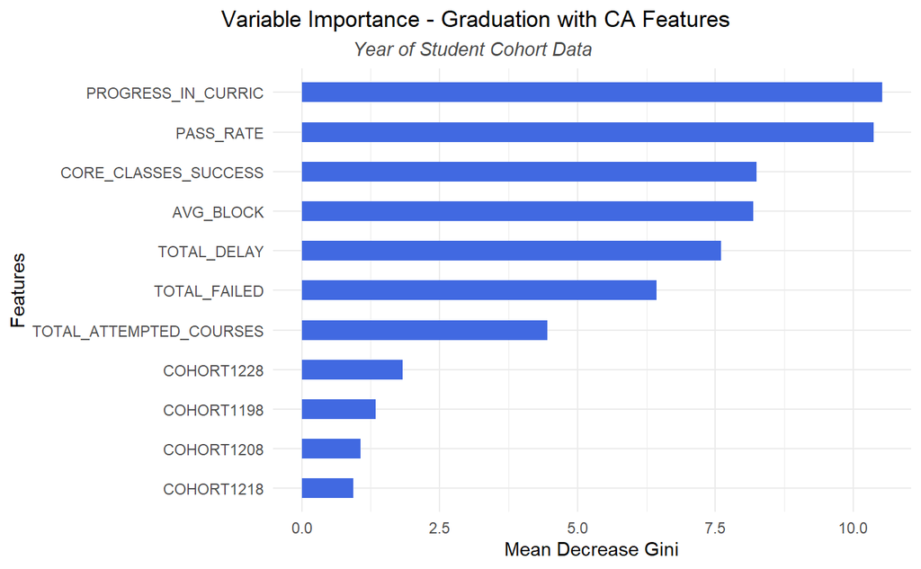